# Flujo de trabajo Machine Learning

Germán Rosati

28 abril, 2025

```r
library(tidyverse)
library(tidymodels)
library(gtsummary)
library(modelsummary)
library(gt)

#options(dplyr.summarise.inform = FALSE)
options(scipen = 999)
```

# Introducción

Operemos con [Tidymodels](https://www.tidymodels.org/) para hacer un modelo de clasificación con el método de la regresión logística. Usaremos nuestra base de juguete de 200 datos ficticios, con la variable objetivo **realiza_trabajo_domestico**. Por ahora, tomaremos únicamente como variables explicativas las horas trabajadas en el mercado y el ingreso total familiar.

Visualicemos previamente estos datos.

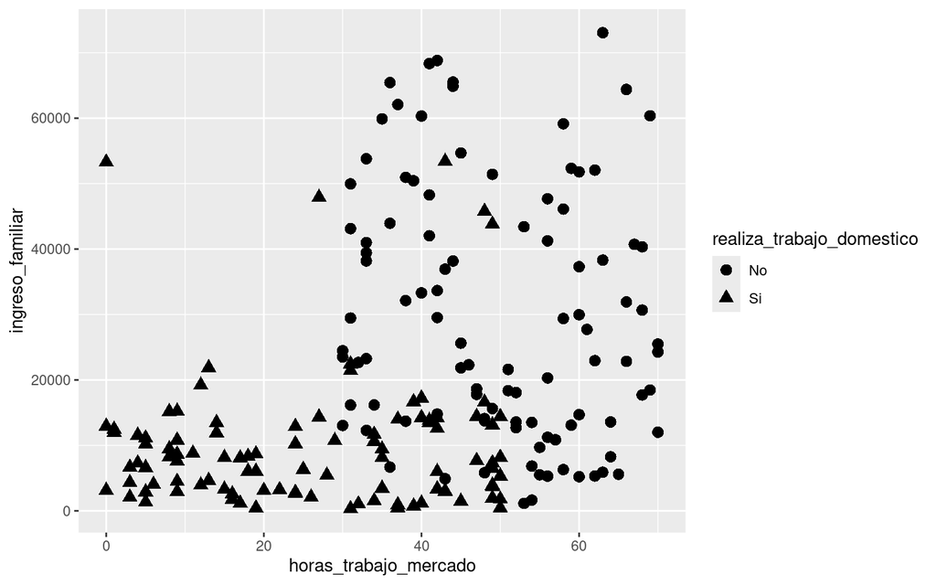

```r
base_juguete <- readRDS(file = "data/eut_juguete_clase4.RDS")


ggplot(base_juguete,aes(x = horas_trabajo_mercado,
                         y = ingreso_familiar,
                         shape = realiza_trabajo_domestico))+
  geom_point(size = 3)
```

Ahora veamos los pasos necesarios para correr el modelo. Luego, discutamos la interpretación de los coeficientes.

## Seteo el tipo de modelo

En formato tidy, comienzo especificando el tipo de modelo. En este caso, **logistic_reg()**. De ser necesario puedo especificar con **set_mode()** el modo del modelo (qué tipo de predicción tiene el outcome, numérica o categórica) Luego, especifico cual es el sistema que utilizaré para estimar el modelo con la función **set_engine()** (en muchos casos responde al paquete que voy a usar para correr el modelo).

```r
log_model <- logistic_reg() %>% #Defino el tipo de modelo
  set_mode("classification") %>%  #el modo (regresión o clasificación)
  set_engine("glm") #el motor sera de "Generalized linear models"
log_model
```

```
## Logistic Regression Model Specification (classification)
##
## Computational engine: glm
```

## Fiteo (entreno) el modelo

Tomo la especificación anterior y explicito qué variables usaré y de que dataset.

*Importante:* La variable objetivo `realiza_trabajo_domestico` **debo convertirla en factor** para correr una regresión logistica (es decir, que sea una variable con categorías). Por otra parte, si van a utilizar funciones que calculan métricas derivadas de la matriz de confusión es mucho muy importante que las **categorías estén ordenadas con el valor positivo como primer nivel y el negativo como el segundo nivel**

```r
base_para_modelar <- base_juguete %>%
  mutate(realiza_trabajo_domestico = factor(realiza_trabajo_domestico))

#Lo entreo con los datos
log_fiteado <- log_model %>%
  fit(realiza_trabajo_domestico ~ horas_trabajo_mercado+ingreso_familiar,
      data = base_para_modelar)
```

### Veamos resultados de los parámetros estimados

```r
tidy(log_fiteado)
```

```
## # A tibble: 3 × 5
##   term                    estimate std.error statistic  p.value
##   <chr>                      <dbl>     <dbl>     <dbl>    <dbl>
## 1 (Intercept)            7.01      1.12           6.24 4.47e-10
## 2 horas_trabajo_mercado -0.130     0.0224        -5.84 5.26e- 9
## 3 ingreso_familiar      -0.0000995 0.0000194     -5.13 2.86e- 7
```

El paquete `modelsummary` y su función homónima nos arroja también datos sobre la bondad de ajuste del modelo. Tenemos medidas como el Akaike information criterion (AIC) y el Bayesian Information Criterion (BIC). Una herramienta interesante es que podemos pasar una lista de modelos y comparar entre ellos. Solo para estos fines, entrenemos otro modelo que también incluye la variable de menores en el hogar.

```r
log_fiteado2 <- log_model %>%
  fit(realiza_trabajo_domestico ~ horas_trabajo_mercado+ingreso_familiar+menores_hogar,
      data = base_para_modelar)


modelsummary::modelsummary(
  list("logistica 2 predictores " = log_fiteado,
       "logistica 3 predictores" = log_fiteado2)
  )
```

|  | logistica 2 predictores | logistica 3 predictores |
| --- | --- | --- |
| (Intercept) | 7.006 | 5.406 |
|  | (1.123) | (1.225) |
| horas_trabajo_mercado | -0.130 | -0.131 |
|  | (0.022) | (0.026) |
| ingreso_familiar | -0.000 | -0.000 |
|  | (0.000) | (0.000) |
| menores_hogarSi |  | 2.684 |
|  |  | (0.553) |
| Num.Obs. | 200 | 200 |
| AIC | 131.4 | 104.1 |
| BIC | 141.3 | 117.3 |
| RMSE | 0.31 | 0.28 |

*Aclaración:* Dado que nos interesan más otro tipo de métricas, no veremos en detalle la estimación de medidas de bondad de ajuste como AIC y BIC. A los fines prácticos basta con tener noción de que:

- Su utilidad es para **comparar modelos** (la interpretación del AIC o BIC de 1 modelo en si mismo es irrelevante)
- Las formulas de AIC y BIC tienen la siguiente “pinta”: $xIC= complejidad-ajuste$.  
  Un termino positivo que actua como penalización a la complejidad del modelo (asociado a la cantidad de parametros o variables que utiliza). Un termino restando asociado a la capacidad de ajuste del modelo (vinculada a la **máxima verosimilitud**, es decir, cuan cerca le paso a los valores reales con mi predicción de probabilidad)
- Al comparar dos modelos, son mejores **los que tienen menor valor de AIC o BIC**.
- En el ejemplo anterior, a pesar de haber agregado complejidad en el 2do modelo (1 variable más), ganamos mucho en ajuste, por eso el AIC y BIC son más bajos.

## Predicción

### Aplicado sobre datos nuevos

Si queremos sólo obtener la predicción que nuestro modelo hará sobre un nuevo par de datos, la función `predict()` requiere como imput un data.frame que contenga columnas nombradas igual que los predictores de nuestro modelo y devuelve, en el mismo orden, las predicciones para la variable Y.

```r
data_nueva<- data.frame(horas_trabajo_mercado = c(40,13),
                        ingreso_familiar = c(60000,10000))

predict(object = log_fiteado,new_data = data_nueva)
```

```
## # A tibble: 2 × 1
##   .pred_class
##   <fct>
## 1 No
## 2 Si
```

Una función que puede resultar todavía más úlil que `predict()` es `augment()`. Al pasarle un modelo entrenado y un dataset para realizar predicciones, esta última añade a dicho dataset el valor de la clase predicha y también las probabilidades estimadas que respaldan dicha predicción

```r
augment(x = log_fiteado,new_data = data_nueva)
```

```
## # A tibble: 2 × 5
##   .pred_class .pred_No .pred_Si horas_trabajo_mercado ingreso_familiar
##   <fct>          <dbl>    <dbl>                 <dbl>            <dbl>
## 1 No            0.985    0.0150                    40            60000
## 2 Si            0.0132   0.987                     13            10000
```

### Aplicado sobre el total de la base

Tomemos la función `augment()` para agregar a nuestro dataset **base_para_modelar** las probabilidades asignadas por nuestro modelo a cada uno de los calsos, y por ende, la clase predicha

```r
base_con_pred<- augment(x = log_fiteado, base_para_modelar) %>%
  mutate(prediccion_gw = ifelse(.pred_No > 0.8,yes = "No",no = "Si"))

base_con_pred
```

```
## # A tibble: 200 × 8
##    .pred_class .pred_No .pred_Si realiza_trabajo_domestico horas_trabajo_mercado
##    <fct>          <dbl>    <dbl> <fct>                                     <int>
##  1 No             0.805   0.195  No                                           56
##  2 Si             0.405   0.595  No                                           33
##  3 No             0.985   0.0147 No                                           36
##  4 No             0.965   0.0348 No                                           70
##  5 Si             0.288   0.712  No                                           43
##  6 Si             0.341   0.659  No                                           30
##  7 No             0.957   0.0431 No                                           39
##  8 No             0.858   0.142  No                                           51
##  9 No             0.937   0.0632 No                                           64
## 10 No             0.829   0.171  No                                           52
## # ℹ 190 more rows
## # ℹ 3 more variables: ingreso_familiar <dbl>, menores_hogar <chr>,
## #   prediccion_gw <chr>
```

## Metricas de evaluación

### Matriz de confusión

Sobre la base de los valores reales y los valores predichos podríamos tomar la matriz de confusión como un tabulado bivariado entre ambas columas

```r
matriz_confusion <- conf_mat(data = base_con_pred,
                             truth = realiza_trabajo_domestico,
                             estimate = .pred_class)

matriz_confusion
```

```
##           Truth
## Prediction No Si
##         No 86 12
##         Si 14 88
```

> ¿Quien se anima a leer estos resultados?

### Métricas derivadas de la matriz

Accuracy, Sensitividad/Recall, Specificity y Precision

```r
accu <- accuracy(data = base_con_pred,
            truth = realiza_trabajo_domestico,
            estimate =  .pred_class)

accu
```

```
## # A tibble: 1 × 3
##   .metric  .estimator .estimate
##   <chr>    <chr>          <dbl>
## 1 accuracy binary          0.87
```

```r
sens <- sensitivity(base_con_pred,truth = realiza_trabajo_domestico,estimate =  .pred_class)

spec <- specificity(base_con_pred,truth = realiza_trabajo_domestico,estimate =  .pred_class)

prec <- precision(base_con_pred,truth = realiza_trabajo_domestico,estimate =  .pred_class)

bind_rows(accu,sens,spec,prec)
```

```
## # A tibble: 4 × 3
##   .metric     .estimator .estimate
##   <chr>       <chr>          <dbl>
## 1 accuracy    binary         0.87
## 2 sensitivity binary         0.86
## 3 specificity binary         0.88
## 4 precision   binary         0.878
```

Veamos esto de forma gráfica para tratar de entender como está operando nuestro modelo:  
En este gráfico utilizamos el parametro **shape** ara distinguir el valor real de la variable objetivo (“No” o “Si”) y el **color** para mostrar las probabildiades de pertenecer a la clase “Si” estimadas por nuestro modelo.

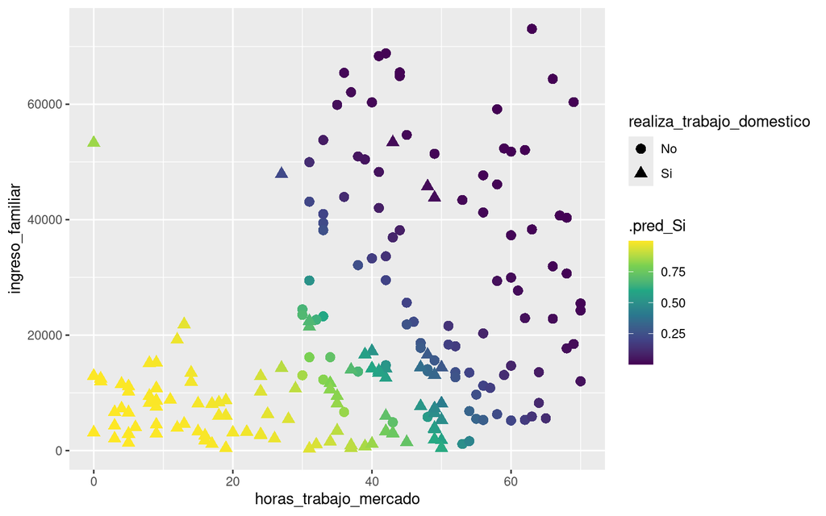

```r
ggplot(base_con_pred,aes(x = horas_trabajo_mercado,
                         y = ingreso_familiar,
                         shape = realiza_trabajo_domestico,
                         color = .pred_Si))+
  geom_point(size = 3)+
  scale_color_viridis_c()
```

En este otro utilizamos el **color** no para mostrar las probabildiades, sino para ver la clase predicha por nuestro modelo (lo que tenia probabilidad mayor a 0,5 queda como “Si”, los menores a 0,5 como “No”). Ver como la “decision boundary” parece ser líneal.

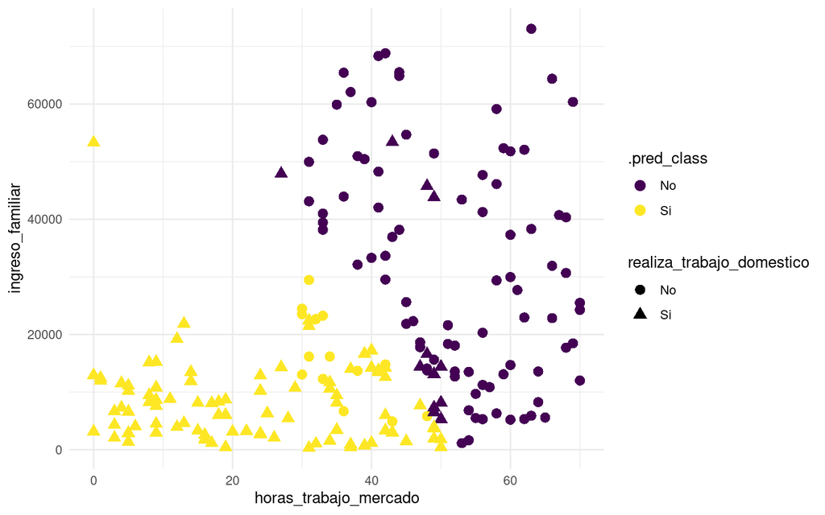

```r
ggplot(base_con_pred,aes(x = horas_trabajo_mercado,
                         y = ingreso_familiar,
                         shape = realiza_trabajo_domestico,
                         color = .pred_class))+
  geom_point(size = 3)+
  scale_color_viridis_d()+
  theme_minimal()
```

> El ejercicio anterior tiene un problema. Utilizamos para evaluar la performance del modelo los mismos datos que utilizamos para entrenarlo. Eso es potencialmente peligroso por posible **OVERFITTING**.

## Train-test split

Hagamos un modelo nuevo con un split de la base original en test y train. Aclaración: Si queremos resultados replicables debemos **setear una semilla** con `set.seed()`, para guardar el mecanismo de pseudo-aleatorización que realiza la computadora.

### Split train-test

```r
set.seed(18/12/2022)
base_spliteada <-  initial_split(base_para_modelar,prop = 0.8)
base_train <-  training(base_spliteada)
base_test <-  testing(base_spliteada)
```

### Fiteo

```r
#log_model <- logistic_reg() %>% # Ya lo corri arriba este paso
#  set_engine("glm")

modelo_sobre_train <- log_model  %>%
  fit(realiza_trabajo_domestico ~ horas_trabajo_mercado+ingreso_familiar,
      data = base_train)

tidy(modelo_sobre_train)
```

```
## # A tibble: 3 × 5
##   term                    estimate std.error statistic      p.value
##   <chr>                      <dbl>     <dbl>     <dbl>        <dbl>
## 1 (Intercept)            7.58      1.39           5.43 0.0000000553
## 2 horas_trabajo_mercado -0.139     0.0276        -5.04 0.000000463
## 3 ingreso_familiar      -0.0000935 0.0000197     -4.76 0.00000196
```

### Aplico predicciones a la base de testeo

```r
base_test_con_pred <- augment(x = modelo_sobre_train,new_data = base_test)
base_test_con_pred
```

```
## # A tibble: 40 × 7
##    .pred_class .pred_No .pred_Si realiza_trabajo_domestico horas_trabajo_mercado
##    <fct>          <dbl>    <dbl> <fct>                                     <int>
##  1 No             0.972  0.0277  No                                           36
##  2 No             0.964  0.0357  No                                           70
##  3 Si             0.244  0.756   No                                           43
##  4 Si             0.248  0.752   No                                           30
##  5 No             0.825  0.175   No                                           51
##  6 No             0.931  0.0686  No                                           64
##  7 Si             0.209  0.791   No                                           34
##  8 No             0.990  0.00994 No                                           66
##  9 No             0.978  0.0218  No                                           45
## 10 Si             0.268  0.732   No                                           38
## # ℹ 30 more rows
## # ℹ 2 more variables: ingreso_familiar <dbl>, menores_hogar <chr>
```

### Matriz de confusión

Sobre la base de los valores reales y los valores predichos podríamos tomar la matriz de confusión como un tabulado bivariado entre ambas columas

```r
matriz_confusion_test<- conf_mat(data = base_test_con_pred,
                                 truth =realiza_trabajo_domestico,
                                 estimate =.pred_class)

matriz_confusion_test
```

```
##           Truth
## Prediction No Si
##         No 22  1
##         Si  6 11
```